# Assignment7

Abigail Griffin

2023-02-03

## Daily Assignment 7

### Data wrangling and plotting

1. Using the built-in starwars data set in the dplyr package, create a new tibble with the following modifications:
- It only includes the species that have more than 1 individual represented in the data set. (hint: first use dplyr to summarize the number of individuals per species in the data frame; then create a vector/tibble of those names; subset the species that are included in that vector)

```r
library(dplyr)
data(starwars)

newtibble<-starwars %>%
  group_by(species) %>%
  summarize(TotalNumber=n(), .groups='drop')

starwars_speciesgr1<-filter(newtibble, TotalNumber > 1)
print(starwars_speciesgr1)
```

```
## # A tibble: 9 × 2
##   species  TotalNumber
##   <chr>          <int>
## 1 Droid              6
## 2 Gungan             3
## 3 Human             35
## 4 Kaminoan           2
## 5 Mirialan           2
## 6 Twi'lek            2
## 7 Wookiee            2
## 8 Zabrak             2
## 9 <NA>               4
```

- It only includes the columns that are not of type list (hint: use glimpse to check)

```r
glimpse(starwars_speciesgr1)
```

```
## Rows: 9
## Columns: 2
## $ species     <chr> "Droid", "Gungan", "Human", "Kaminoan", "Mirialan", "Twi'l…
## $ TotalNumber <int> 6, 3, 35, 2, 2, 2, 2, 2, 4
```

```r
nottypelist<-filter(starwars, species %in% c("Droid", "Gungan", "Human", "Kaminoan", "Mirialan", "Twi'lek", "Wookiee", "Zabrak")) # subsetting characters with these names
print(nottypelist)
```

```
## # A tibble: 54 × 14
##    name        height  mass hair_…¹ skin_…² eye_c…³ birth…⁴ sex   gender homew…⁵
##    <chr>        <int> <dbl> <chr>   <chr>   <chr>     <dbl> <chr> <chr>  <chr>
##  1 Luke Skywa…    172    77 blond   fair    blue       19   male  mascu… Tatooi…
##  2 C-3PO          167    75 <NA>    gold    yellow    112   none  mascu… Tatooi…
##  3 R2-D2           96    32 <NA>    white,… red        33   none  mascu… Naboo
##  4 Darth Vader    202   136 none    white   yellow     41.9 male  mascu… Tatooi…
##  5 Leia Organa    150    49 brown   light   brown      19   fema… femin… Aldera…
##  6 Owen Lars      178   120 brown,… light   blue       52   male  mascu… Tatooi…
##  7 Beru White…    165    75 brown   light   blue       47   fema… femin… Tatooi…
##  8 R5-D4           97    32 <NA>    white,… red        NA   none  mascu… Tatooi…
##  9 Biggs Dark…    183    84 black   light   brown      24   male  mascu… Tatooi…
## 10 Obi-Wan Ke…    182    77 auburn… fair    blue-g…    57   male  mascu… Stewjon
## # … with 44 more rows, 4 more variables: species <chr>, films <list>,
## #   vehicles <list>, starships <list>, and abbreviated variable names
## #   ¹hair_color, ²skin_color, ³eye_color, ⁴birth_year, ⁵homeworld
```

2. Clean your data set: only include observations/rows that do not have an NA in the height column.

```r
anyNA(nottypelist)
```

```
## [1] TRUE
```

```r
cleanstarwars_height<-nottypelist[complete.cases(nottypelist[,2]),] # removes NA in second column (height)
print(cleanstarwars_height)
```

```
## # A tibble: 49 × 14
##    name        height  mass hair_…¹ skin_…² eye_c…³ birth…⁴ sex   gender homew…⁵
##    <chr>        <int> <dbl> <chr>   <chr>   <chr>     <dbl> <chr> <chr>  <chr>
##  1 Luke Skywa…    172    77 blond   fair    blue       19   male  mascu… Tatooi…
##  2 C-3PO          167    75 <NA>    gold    yellow    112   none  mascu… Tatooi…
##  3 R2-D2           96    32 <NA>    white,… red        33   none  mascu… Naboo
##  4 Darth Vader    202   136 none    white   yellow     41.9 male  mascu… Tatooi…
##  5 Leia Organa    150    49 brown   light   brown      19   fema… femin… Aldera…
##  6 Owen Lars      178   120 brown,… light   blue       52   male  mascu… Tatooi…
##  7 Beru White…    165    75 brown   light   blue       47   fema… femin… Tatooi…
##  8 R5-D4           97    32 <NA>    white,… red        NA   none  mascu… Tatooi…
##  9 Biggs Dark…    183    84 black   light   brown      24   male  mascu… Tatooi…
## 10 Obi-Wan Ke…    182    77 auburn… fair    blue-g…    57   male  mascu… Stewjon
## # … with 39 more rows, 4 more variables: species <chr>, films <list>,
## #   vehicles <list>, starships <list>, and abbreviated variable names
## #   ¹hair_color, ²skin_color, ³eye_color, ⁴birth_year, ⁵homeworld
```

- Then, use dplyr to print a summary table showing the mean, median, and standard deviation of height for **each species**

```r
starwars_heightsummary<-cleanstarwars_height %>%
  group_by(species) %>%
  summarize(meanHeight=mean(height), medHeight=median(height), stdevHeight=sd(height), .groups='drop')
print(starwars_heightsummary)
```

```
## # A tibble: 8 × 4
##   species  meanHeight medHeight stdevHeight
##   <chr>         <dbl>     <dbl>       <dbl>
## 1 Droid          131.        97       49.1
## 2 Gungan         209.       206       14.2
## 3 Human          177.       180       12.5
## 4 Kaminoan       221        221       11.3
## 5 Mirialan       168        168        2.83
## 6 Twi'lek        179        179        1.41
## 7 Wookiee        231        231        4.24
## 8 Zabrak         173        173        2.83
```

3. Create a box plot figure that shows the variation in heights among Star Wars species. Do the values in your summary table line up with the plot? Code so that each box plot (Species) is be filled with a different color. Change your axes labels so that species is capitalized and height is capitalized and shows units (cm). Use the theme_minimal option. Then look into the annotate or geom_text functions and add the text “p=1.2E-0.5” to the top right corner.

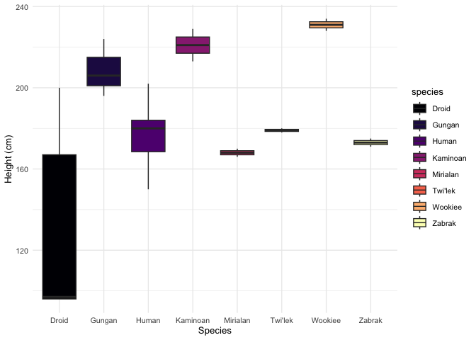

```r
library(ggplot2)
library(viridis)
cols<-viridis(8, option = "magma") # assign 8 different "magma" color options from viridis package to "cols" so I can call it to fill the species key colors
starwars_heightboxplot<-ggplot(data=cleanstarwars_height, aes(x=species,y=height, fill=species)) + # ggplot code structure
  geom_boxplot() + # create a boxplot
  scale_fill_manual(values=cols) + # fill scale colors with "magma" from viridis, as assigned above
  xlab("Species") + # add "Species" as x axis label
  ylab("Height (cm)") + # add "Height (cm)" as y axis label
  theme_minimal(base_size=10) # add minimalist theme (no background) and set base font size as 10
print(starwars_heightboxplot)
```

*For an extra (optional) challenge*: overlay the data points onto the box plots (hint: look into geom_jitter or geom_point). See if you can change the color of the points, depending on the gender or sex variables.

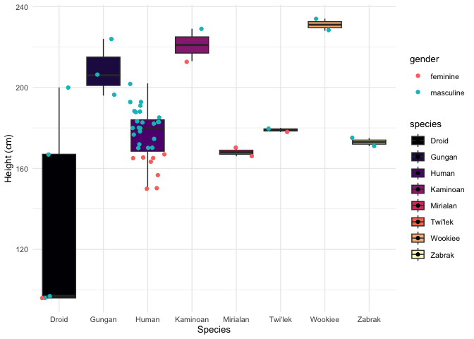

```r
starwars_heightboxplot +
  geom_jitter(aes(colour = gender)) # trying both geom_jitter and geom_point
```

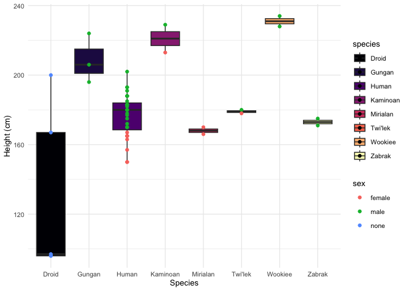

```r
starwars_heightboxplot +
  geom_point(aes(colour = sex))
```

4. Using the same or a different built-in data set, create at least one additional (and different kind of) plot. Experiment with different arguments, features, and colors.
- **Comparing Sepal Length to Petal Length in Iris Species**

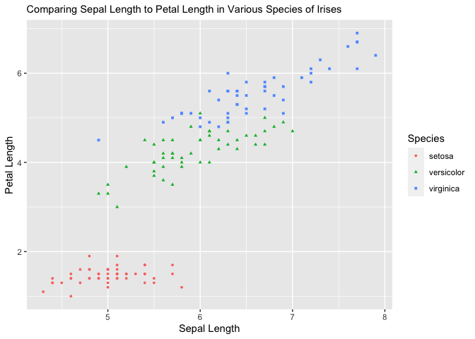

```r
i1<-ggplot(data=iris, mapping=aes(x=Sepal.Length, y=Petal.Length, color=Species, shape=Species)) +
  geom_point(size=1) +
  xlab("Sepal Length") +
  ylab("Petal Length") +
  labs(title="Comparing Sepal Length to Petal Length in Various Species of Irises") +
  theme(plot.title = element_text(size=11))
i1
```

- **UCB Admission to Department By Sex**

```r
# Using UCBAdmissions data, which includes # of acceptances and rejections to depts by sex
class(UCBAdmissions)
```

```
## [1] "table"
```

```r
ftable2df<-function(mydata) {
  ifelse(class(mydata) == "ftable",
         mydata <- mydata, mydata <- ftable(mydata))
  dfrows <- rev(expand.grid(rev(attr(mydata, "row.vars"))))
  dfcols <- as.data.frame.matrix(mydata)
  names(dfcols) <- do.call(
    paste, c(rev(expand.grid(rev(attr(mydata, "col.vars")))), sep = "_"))
  cbind(dfrows, dfcols)
} # not my code, but this allowed me to convert table data into a df!
ucb_table<-transform(ftable2df(ftable(UCBAdmissions, row.vars = 3:2)),
  Applications = Admitted + Rejected)

ucb_admit_plot<-ggplot(data=ucb_table, aes(x=Dept, y=Admitted, fill=Gender)) +
  geom_col(position=position_dodge()) + # creating a bar plot to compare # of admits based on sex
  xlab("Department") + # add x axis label
  ylab("# of Admits") +
  labs(title="UCB Admission to Department By Sex") +
  labs(fill='Sex') +
    geom_text(aes(label=Admitted), vjust=-0.4, position=position_dodge(width=1), color="black", size=2) +
  scale_fill_manual(values=c("darkcyan","limegreen"))
```

- **Effect of Chicken Diet on Growth Over Time**

```r
# Using ChickWeight, a data set which compares weight to age of chicks on different diets

cwavg <- ChickWeight %>%
  group_by(Diet, Time) %>%
  summarize(meanWeight=mean(weight))
```

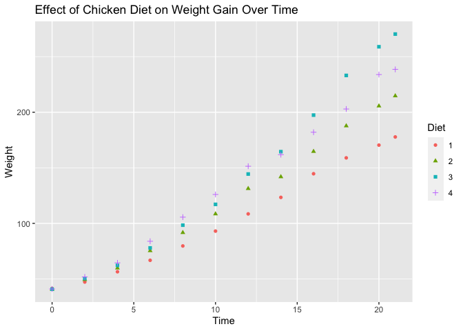

```r
  # large data set, so averaging weight per day

cwavg_scatter<-ggplot(data=cwavg) +
  geom_point(aes(x = Time, y = meanWeight, shape = Diet, color = Diet)) +
  xlab("Time") +
  ylab("Weight") +
  labs(title="Effect of Chicken Diet on Weight Gain Over Time")
print(cwavg_scatter)
```

Finally, create a multi-panel figure with the graphs you created.

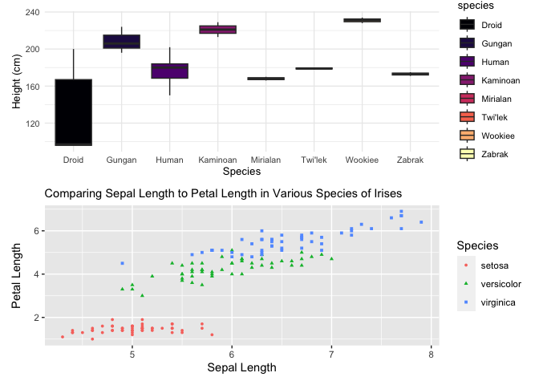

```r
library(patchwork)
print(starwars_heightboxplot / i1) # division symbol puts plots over one another
```

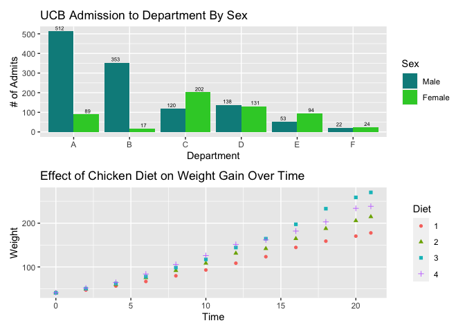

```r
print(ucb_admit_plot / cwavg_scatter)
```